# Homework 1

Group C: Ferfoglia Irene, Berti Michele, Fodor Imola, Babaei Elham

## Core Statistics: Chapter 1

### 1.1

Exponential random variable, $X \ge 0$, has p.d.f. $f (x) = \lambda \exp(-\lambda x)$.
**1. Find the c.d.f. and the quantile function for $X$.**
$$F(x_0)=Pr(X \le x_0)= \int_0^{x_0} \lambda e^{- \lambda x} \ dx = \bigg[- \lambda \frac{e^{-\lambda x}}{\lambda}\bigg]_0^{x_0}= 1-e^{-\lambda x_0}$$
$$\begin{align}p&=1-e^{-\lambda x_0} \\ 1-p&= e^{-\lambda x_0} \\ \ln(1-p)&=-\lambda x_0 \\ -\frac{ln(1-p)}{\lambda}&=x_0=F^{-1}(p)=Q(p)\end{align}$$
**2. Find $Pr(X < \lambda)$ and the median of $X$.**
$$Pr(X \le \lambda)=F(\lambda)=1-e^{-\lambda^2}$$
$$Q(0.5)=-\frac{ln(0.5)}{\lambda}=\frac{ln(2)-\ln(1)}{\lambda}=\frac{ln(2)}{\lambda}$$
**3. Find the mean and variance of $X$.**
$$E(X)=\int_0^{+ \infty} x \, f(x) \ dx = \int_0^{+ \infty}\lambda x \, e^{-\lambda x} \ dx = \bigg[ \frac{e^{-\lambda x}(\lambda x-1)}{\lambda}\bigg]_0^{+\infty}= \frac{1}{\lambda}$$
$$E(X^2)=\int_0^{+ \infty} x^2 \, f(x) \ dx = \int_0^{+ \infty}\lambda x^2 \, e^{-\lambda x} \ dx = \bigg[ \frac{e^{-\lambda x}(\lambda^2 x^2 + 2 \lambda x +2)}{\lambda^2}\bigg]_0^{+\infty}= \frac{2}{\lambda^2}$$
$$var(X)=E(X^2)-E(X)^2= \frac{2}{\lambda^2} - \frac{1}{\lambda^2}= \frac{1}{\lambda^2}$$

### 1.2

**Evaluate $Pr(X < 0.5, Y < 0.5)$ if $X$ and $Y$ have joint p.d.f.**
$$f(x,y)= \begin{cases}x+3/2y^2 \quad &\mathbb{if } \ 0<x<1 \ \mathbb{ and } \ 0<y<1 \\ 0 \quad & \mathbb{otherwise} \end{cases}$$
$$\begin{align} Pr(X<0.5, \ Y<0.5)&= \int_0^{1/2}\int_0^{1/2} x+\frac{3}{2}y^2 \ dx \, dy \\ &= \int_0^{1/2} \bigg[ \frac{x^2}{2}+ \frac{3}{2}xy^2\bigg]_0^{1/2} dy \\ &= \int_0^{1/2} \frac{1}{8}+ \frac{3}{4}y^2 \ dy \\&=\bigg[ \frac{1}{8}y+ \frac{1}{4}y^3\bigg]_0^{1/2} = \frac{3}{32} \approx 0.09375 \end{align}$$

### 1.6

**Let X and Y be non-independent random variables, such that $var(X) = σ^2_x$, $var(Y ) = σ^2_y$ and $cov(X, Y ) = σ^2_{xy}$. Using the result from Section 1.6.2, find var(X + Y) and var(X − Y).**

As $X$ and $Y$ are dependent,
$$\begin{aligned}
Var(X+Y) &= Var(X) + Var(Y) + 2Cov(X,Y)\\
&= \sigma^2_x + \sigma^2_y + 2\sigma^2_{xy}
\end{aligned}$$
$$\begin{aligned}
Var(X-Y) &= Var(X) + Var(Y) - 2Cov(X,Y)\\
&= \sigma^2_x + \sigma^2_y - 2\sigma^2_{xy}
\end{aligned}$$

### 1.8

If $\log(X) \sim N(\mu, \sigma^2)$, find the p.d.f. of $X$. $Y=\log(X) \rightarrow X=e^Y$, so $X$ has a lognormal distribution. Since $Y$ has a normal distribution, its p.d.f. is
$$f_Y(Y)=\frac{1}{\sqrt{2 \pi}\sigma} \ \exp \bigg( - \frac{1}{2 \sigma^2}(x-\mu)^2\bigg)$$
so the p.d.f of $X$ is given by
$$f_x(x)= f_y(y) \, \bigg| \frac{d \, \log(x)}{dx}\bigg|= \frac{1}{\sqrt{2\pi}\sigma x} exp\left({\frac{-(log(x)- \mu)^2}{2\sigma^2}}\right)$$

## Core Statistics: Chapter 3

### 3.3

**Rewrite the following, replacing the loop with efficient code:**

```r
n <- 10000000; z <- rnorm(n)
zneg <- 0;j <- 1
system.time(
  for (i in 1:n) {
    if (z[i]<0) {
      zneg[j] <- z[i]
      j <- j + 1
  }
})
```

```
##    user  system elapsed
##   1.763   0.155   1.918
```

**Confirm that your rewrite is faster but gives the same result.**

```r
system.time({
zneg2 <- z[z < 0]
})
```

```
##    user  system elapsed
##   0.070   0.027   0.098
```

```r
sum(zneg != zneg2)
```

```
## [1] 0
```

### 3.5

Consider solving the matrix equation $Ax=y$ for $x$, where $y$ is a known $n$ vector and $A$ is a known $n \times n$ matrix. The formal solution to the problem is $x=A^{-1}y$, but it is possible to solve the equation directly, without actually forming $A^{-1}$. This question explores the direct solution. Read the help file for `solve` before trying it.

**A. First create an $A$, $x$ and $y$ satisfying $Ax=y$.**

```r
set.seed(0); n <- 1000
A <- matrix(runif(n*n),n,n);
x.true <- runif(n)
y <- A%*%x.true
```

The idea is to experiment with solving $Ax = y$ for $x$, but with a known truth to compare the answer to.

**B. Using `solve`, form the matrix $A^{-1}$ explicitly and then form $x1=A^{-1}y$. Note how long this takes. Also assess the mean absolute difference between `x1` and `x.true` (the apporximate mean absolute error in the solution).**

```r
system.time({
  A_inv = solve(A)
  x1 <- A_inv %*% y
})
```

```
##    user  system elapsed
##   0.651   0.001   0.650
```

```r
mean(abs(x.true - x1))
```

```
## [1] 2.956833e-11
```

**C. Now use `solve` to directly solve for $x$ without forming $A^{-1}$. Note how long this takes and assess the mean absolute error of the result.**

```r
system.time({
  x2 <- solve(A, y)
  }
)
```

```
##    user  system elapsed
##   0.223   0.000   0.224
```

```r
mean(abs(x.true - x2))
```

```
## [1] 1.356142e-12
```

**D. What do you conclude?**

It is better to solve directly the system calling the solve function, it is more efficient and more precise.

### 3.6

The empirical cumulative distribution function for a set of measurements ${x_i : i = 1, . . . n}$ is
$$\hat F(x)= \frac{\# (x_i<x)}{n}$$
where $\#(xi < x)$ denotes ‘number of $x_i$ values less than $x$’. When answering the following, try to ensure that your code is commented, clearly structured, and tested. To test your code, generate random samples using `rnorm`, `runif`, etc.

**A. Write an R function that takes an unordered vector of observations $x$ and returns the values of the empirical c.d.f. for each value, in the order corresponding to the original $x$ vector. See `sort.int`.**

```r
my_ecdf <- function(x){
  r <- sort.int(x, index.return = TRUE)
  x.sorted <- r$x
  idxs <- r$ix

  l <- length(x.sorted)
  m_ecdf <- seq(l)          # just initialize a sequence of length l
  m_ecdf[idxs] <- (1:l) / l # so that this trick to evaluate the ecdf works

  return(m_ecdf)
}
```

**B. Modify your function to take an extra argument `plot.cdf`, that when `TRUE` will cause the empirical c.d.f. to be plotted as a step function over a suitable $x$ range.**

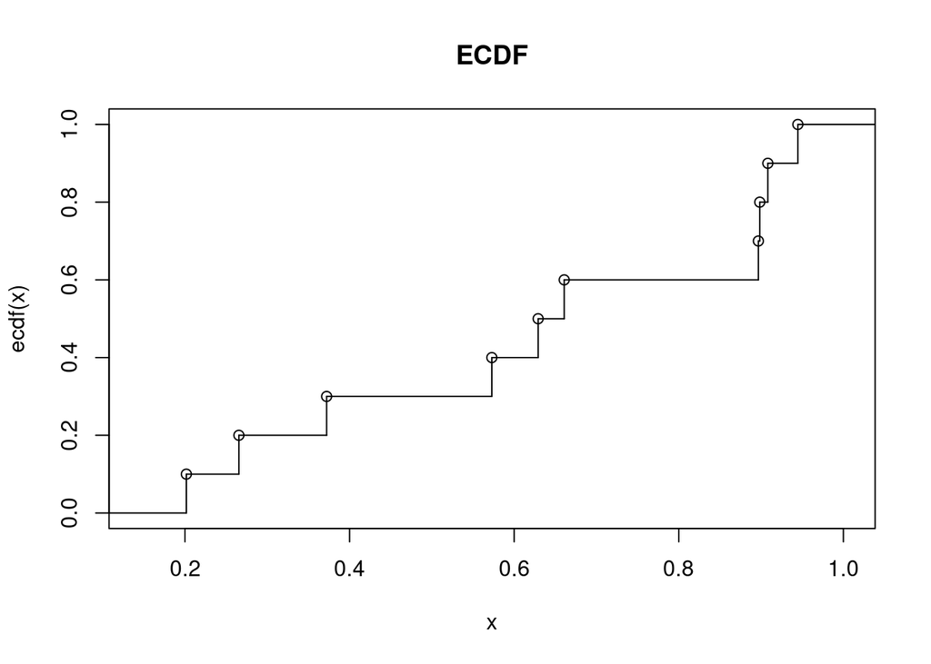

```r
my_ecdf <- function(x, plot.cdf=FALSE){
  r <- sort.int(x, index.return = TRUE)
  x.sorted <- r$x
  idxs <- r$ix

  l <- length(x.sorted)
  m_ecdf <- seq(l)          # just initialize a sequence of length l
  m_ecdf[idxs] <- (1:l) / l # so that this trick to evaluate the ecdf works

  # plotting the ecdef if required
  if(plot.cdf){
    sf = stepfun(x.sorted, (0:l) / l, f=0)
    plot(sf, main="ECDF", ylab = "ecdf(x)", xlab="x")
    }

  return(m_ecdf)
}

n = 10
set.seed(0)
x = runif(n)
m_ecdf <- my_ecdf(x, plot.cdf=TRUE)
```

```r
# checking if it gives the same results of the built-in function
sum(abs(m_ecdf - ecdf(x)(x)))
```

```
## [1] 0
```

## Extra

**Based on the following data, conduct a hypothesis test to determine if the average age of a certain population of interest is equal to $45$ years:**

```r
age <- c(64, 95, 28, 64, 62, 54, 92, 96, 86, 69, 102, 75, 33, 33,68, 86, 45, 37, 59, 20, 33, 18, 7, 18, 38, 66, 45, 66, 80, 69, 58, 44, 41, 70, 25, 51, 71, 68, 13, 38)
```

**What is your conclusion about the null hypothesis for $\alpha=0.01$? (check the assumptions of the test). Plot the density of the test statistic and highlight the rejection region.**

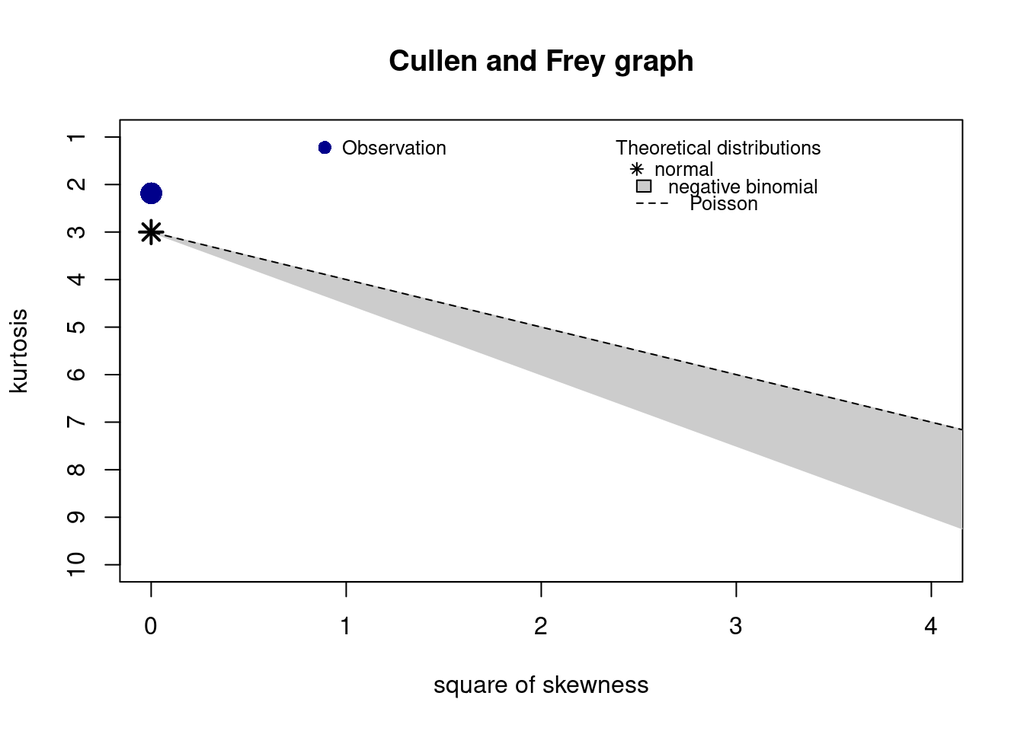

```
## summary statistics
## ------
## min:  7   max:  102
## median:  58.5
## mean:  54.675
## estimated sd:  24.82698
## estimated skewness:  -0.02352123
## estimated kurtosis:  2.183883
```

```r
#checking the assumption of normal distribution
library(fitdistrplus)
descdist(age, discrete = TRUE)
```

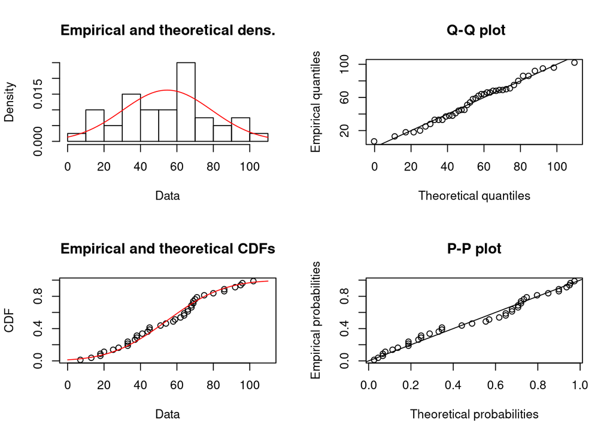

```r
fit.norm <- fitdist(age, "norm")
plot(fit.norm)
```

```r
# 99% confidence level test
#defining probability
alpha = 0.01
p = 1 - alpha
#retrieve value <- probability
c_value = qt(alpha/2, df=39, lower.tail = F)
print(c_value)
```

```
## [1] 2.707913
```

```r
# executing the t test with the built-in function
r = t.test(age, mu=45, alternative="two.sided",conf.level=p)
print(r)
```

```
##
##  One Sample t-test
##
## data:  age
## t = 2.4647, df = 39, p-value = 0.01822
## alternative hypothesis: true mean is not equal to 45
## 99 percent confidence interval:
##  44.04511 65.30489
## sample estimates:
## mean of x
##    54.675
```

By seeing the quantile-quantile plot it seems reasonable to think that the data is normal-distrbuted.

For this reason, the t_test has been used to verify if the data supports the hypotesis $H_0$: $\mu = 45$.

Above it is proven that we got a non-significant result, the p-value is greater than the alpha, hence we are failing to reject the null hypothesis.

Also with the critical value, it being 2.70; and having the rule t<c_value (the distribution we have is symmetrical); we fail to reject the null hypothesis.

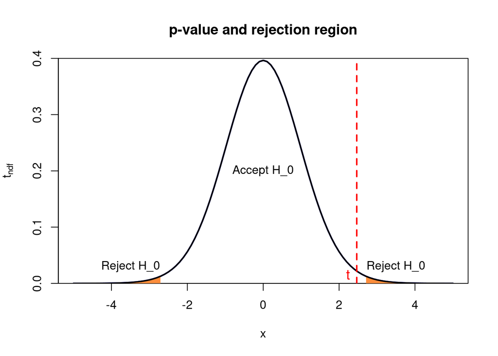

```r
library(RColorBrewer)

# number of degree of freedom
ndf = 39

# defining the quantiles that define the acceptance/rejection region
a <-  alpha / 2
b <- 1 - a

t_interval <- c(qt(a, ndf), qt(b, ndf)) #interval of confidence for the statistcs

# Main plot of density
curve(dt(x,ndf),xlim=c(-5,5), ylim=c(0,0.4),
  main="p-value and rejection region", col = "blue", lwd = 2, xlab="x",  ylab=expression(t[ndf]),  yaxs="i")


library(RColorBrewer)
plotclr <- brewer.pal(6,"YlOrRd")
# Color the area(higher tail)
start_point <- qt(b, ndf)
end_point <-  5
cord.x <- c(start_point,  seq(start_point, end_point, 0.01),  end_point)
cord.y <- c(0,  dt(seq(start_point, end_point, 0.01), ndf ),  0)
polygon(cord.x, cord.y, col=plotclr[4], border = NA )

# Color the area(lower tail)
start_point <- -5
end_point <-  qt(a, ndf)
cord.x <- c(start_point,  seq(start_point, end_point, 0.01),  end_point)
cord.y <- c(0,  dt(seq(start_point, end_point, 0.01), ndf ),  0)
polygon(cord.x, cord.y, col=plotclr[4], border = NA )

# Plot again because it's covered
curve(dt(x,ndf),xlim=c(-5,5),main=expression(t[ndf]),  lwd = 2, add = TRUE, yaxs="i")


# Vertical line of statistic
abline(v =r$statistic, lty=2, lwd=2, col="red")

#Adding some texts
text (0,0.2, paste("Accept", expression(H_0)))
text (3.5,0.03, paste("Reject", expression(H_0)))
text (-3.5,0.03, paste("Reject", expression(H_0)))
text(as.double(r$statistic)-0.23, 0.015, "t", col="red", cex=1.2)
```